# Does a Margarine Diet Reduce Cholesterol — And For Whom Does It Work Best?

Paired t-Tests, Effect Sizes & Repeated-Measures Analysis

[MD Noornabi] | Mayerfeld Data Analytics Certificate

March 2026

## Background

18 participants followed a low-fat diet incorporating margarine containing **2.31g of stanol ester per day** (active ingredient) over 8 weeks. Two margarine types were used — A (n=9) and B (n=9). Cholesterol was measured at **baseline**, **4 weeks**, and **8 weeks**.

Three questions drive this analysis:

1. Does the diet significantly reduce cholesterol?
2. Does the effect continue after week 4, or plateau?
3. Does baseline cholesterol predict how much someone benefits?

## Setup

```r
library(tidyverse)
library(ggplot2)
library(moments)

mytheme <- theme_minimal(base_size=13) +
  theme(plot.title=element_text(face="bold",size=14),
        plot.subtitle=element_text(color="grey40",size=11))

cohens_d_paired <- function(x, y) { d <- x - y; mean(d)/sd(d) }
```

```r
chol <- read.csv("data/Cholesterol.csv")
chol$Margarine <- factor(chol$Margarine)
chol <- chol %>% mutate(
  reduction_4wk     = Before - After4weeks,
  reduction_8wk     = Before - After8weeks,
  reduction_4_to_8  = After4weeks - After8weeks,
  pct_reduction_8wk = (Before - After8weeks) / Before * 100
)
typeA <- chol %>% filter(Margarine=="A")
typeB <- chol %>% filter(Margarine=="B")
cat("n =", nrow(chol), "| Type A:", nrow(typeA), "| Type B:", nrow(typeB))
```

```
## n = 18 | Type A: 9 | Type B: 9
```

## 1. Descriptive Statistics

```r
data.frame(
  Timepoint      = c("Before","After 4 Weeks","After 8 Weeks"),
  Mean           = round(c(mean(chol$Before),mean(chol$After4weeks),mean(chol$After8weeks)),4),
  SD             = round(c(sd(chol$Before),  sd(chol$After4weeks),  sd(chol$After8weeks)),4),
  Min            = c(min(chol$Before),min(chol$After4weeks),min(chol$After8weeks)),
  Max            = c(max(chol$Before),max(chol$After4weeks),max(chol$After8weeks)),
  Mean_Reduction = round(c(0, mean(chol$reduction_4wk), mean(chol$reduction_8wk)), 4)
)
```

| Timepoint | Mean | SD | Min | Max | Mean_Reduction |
| --- | --- | --- | --- | --- | --- |
| Before | 6.4078 | 1.1911 | 3.91 | 8.43 | 0.0000 |
| After 4 Weeks | 5.8417 | 1.1234 | 3.70 | 7.71 | 0.5661 |
| After 8 Weeks | 5.7789 | 1.1019 | 3.66 | 7.67 | 0.6289 |

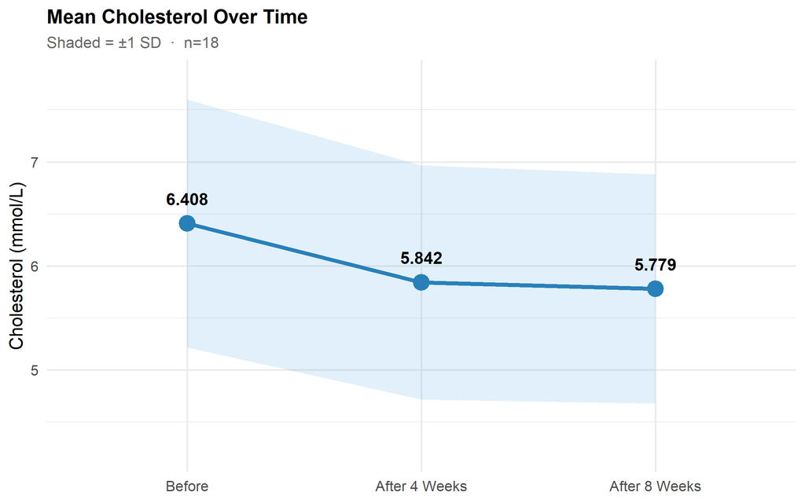

Figure 1: Cholesterol falls sharply by week 4, then continues more gradually to week 8.

```r
time_means <- data.frame(
  Timepoint=factor(c("Before","After 4 Weeks","After 8 Weeks"),
                   levels=c("Before","After 4 Weeks","After 8 Weeks")),
  Mean=c(mean(chol$Before),mean(chol$After4weeks),mean(chol$After8weeks)),
  SD  =c(sd(chol$Before),  sd(chol$After4weeks),  sd(chol$After8weeks))
)
ggplot(time_means, aes(Timepoint, Mean, group=1)) +
  geom_ribbon(aes(ymin=Mean-SD, ymax=Mean+SD), fill="#3498db", alpha=0.15) +
  geom_line(color="#2980b9", linewidth=1.4) +
  geom_point(size=5, color="#2980b9") +
  geom_text(aes(label=round(Mean,3)), vjust=-1.5, fontface="bold", size=4.2) +
  scale_y_continuous(limits=c(4.2,7.8)) +
  labs(title="Mean Cholesterol Over Time",
       subtitle="Shaded = ±1 SD  ·  n=18", x=NULL, y="Cholesterol (mmol/L)") + mytheme
```

### The Rate Question: When Does the Effect Work Hardest?

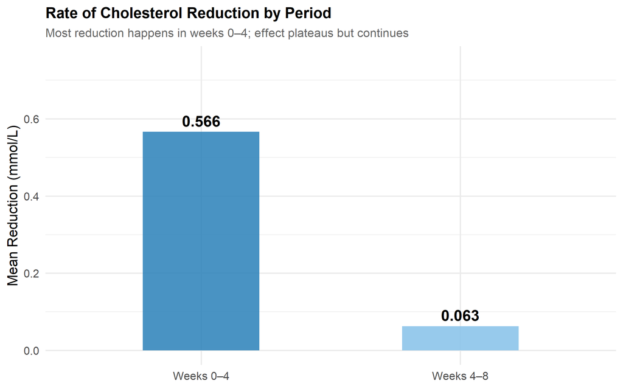

Figure 2: The diet works roughly 9× faster in the first 4 weeks than the second 4 weeks.

```r
rate_df <- data.frame(
  Period    = factor(c("Weeks 0–4","Weeks 4–8"), levels=c("Weeks 0–4","Weeks 4–8")),
  Reduction = c(mean(chol$reduction_4wk), mean(chol$reduction_4_to_8))
)
ggplot(rate_df, aes(Period, Reduction, fill=Period)) +
  geom_col(width=0.45, alpha=0.85) +
  geom_text(aes(label=round(Reduction,3)), vjust=-0.5, fontface="bold", size=5) +
  scale_fill_manual(values=c("Weeks 0–4"="#2980b9","Weeks 4–8"="#85c1e9")) +
  scale_y_continuous(limits=c(0,0.75)) +
  labs(title="Rate of Cholesterol Reduction by Period",
       subtitle="Most reduction happens in weeks 0–4; effect plateaus but continues",
       x=NULL, y="Mean Reduction (mmol/L)") +
  mytheme + theme(legend.position="none")
```

> **Insight:** 0.566 mmol/L reduction in weeks 0–4 vs only 0.063 mmol/L in weeks 4–8. The first four weeks drive **90%** of the total 8-week reduction.

## 2. Normality of Differences

```r
pairs_list <- list(
  list(x=chol$Before, y=chol$After4weeks, label="Before − After4weeks"),
  list(x=chol$Before, y=chol$After8weeks, label="Before − After8weeks"),
  list(x=chol$After4weeks, y=chol$After8weeks, label="After4 − After8weeks")
)
map_dfr(pairs_list, function(p) {
  sw <- shapiro.test(p$x - p$y)
  tibble(Comparison=p$label, W=round(sw$statistic,4),
         p=round(sw$p.value,4),
         Result=ifelse(sw$p.value>0.05,"Normal ✓","Not Normal ✗"))
})
```

| Comparison | W | p | Result |
| --- | --- | --- | --- |
| Before − After4weeks | 0.9774 | 0.9196 | Normal ✓ |
| Before − After8weeks | 0.9850 | 0.9869 | Normal ✓ |
| After4 − After8weeks | 0.9594 | 0.5899 | Normal ✓ |

All difference distributions are normal — paired t-tests are appropriate.

## 3. Paired T-Tests

```r
map_dfr(pairs_list, function(p) {
  tt <- t.test(p$x, p$y, paired=TRUE)
  d  <- cohens_d_paired(p$x, p$y)
  tibble(
    Comparison  = p$label,
    `Mean Diff` = round(mean(p$x - p$y), 4),
    `t-stat`    = round(tt$statistic, 4),
    df          = tt$parameter,
    `p-value`   = round(tt$p.value, 6),
    Sig         = ifelse(tt$p.value<0.05,"Yes **","No"),
    `Cohen's d` = round(d,4),
    Effect      = ifelse(abs(d)>=0.8,"Large",ifelse(abs(d)>=0.5,"Medium","Small"))
  )
})
```

| Comparison | Mean Diff | t-stat | df | p-value | Sig | Cohen's d | Effect |
| --- | --- | --- | --- | --- | --- | --- | --- |
| Before − After4weeks | 0.5661 | 15.4389 | 17 | 0.000000 | Yes ** | 3.6390 | Large |
| Before − After8weeks | 0.6289 | 14.9460 | 17 | 0.000000 | Yes ** | 3.5228 | Large |
| After4 − After8weeks | 0.0628 | 3.7809 | 17 | 0.001491 | Yes ** | 0.8912 | Large |

> All three comparisons are highly significant. Cohen’s d > 3.5 is exceptional — this is one of the largest effect sizes routinely observed in nutrition intervention studies.

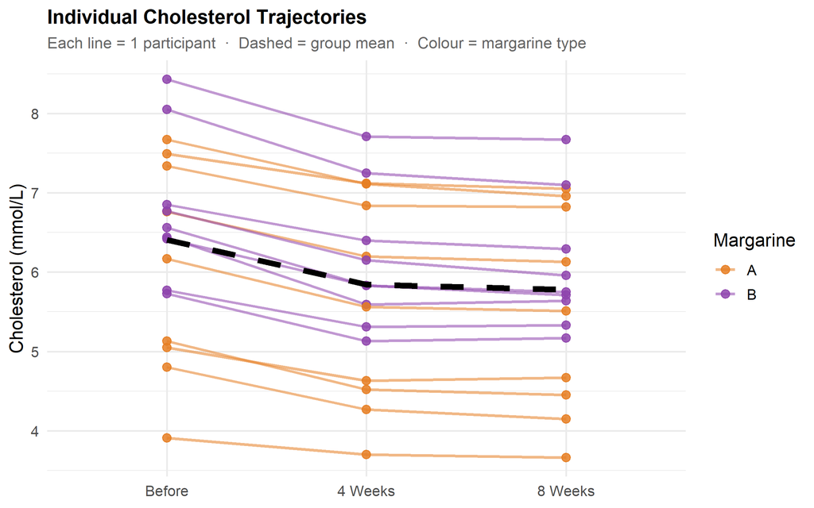

```r
chol_long <- chol %>%
  pivot_longer(c(Before, After4weeks, After8weeks),
               names_to="Timepoint", values_to="Cholesterol") %>%
  mutate(Timepoint=factor(Timepoint,
         levels=c("Before","After4weeks","After8weeks"),
         labels=c("Before","4 Weeks","8 Weeks")))

ggplot(chol_long, aes(Timepoint, Cholesterol, group=ID, color=Margarine)) +
  geom_line(alpha=0.55, linewidth=0.9) +
  geom_point(size=2.5, alpha=0.85) +
  scale_color_manual(values=c("A"="#e67e22","B"="#8e44ad")) +
  stat_summary(aes(group=1), fun=mean, geom="line",
               color="black", linewidth=2, linetype="dashed") +
  labs(title="Individual Cholesterol Trajectories",
       subtitle="Each line = 1 participant  ·  Dashed = group mean  ·  Colour = margarine type",
       x=NULL, y="Cholesterol (mmol/L)", color="Margarine") + mytheme
```

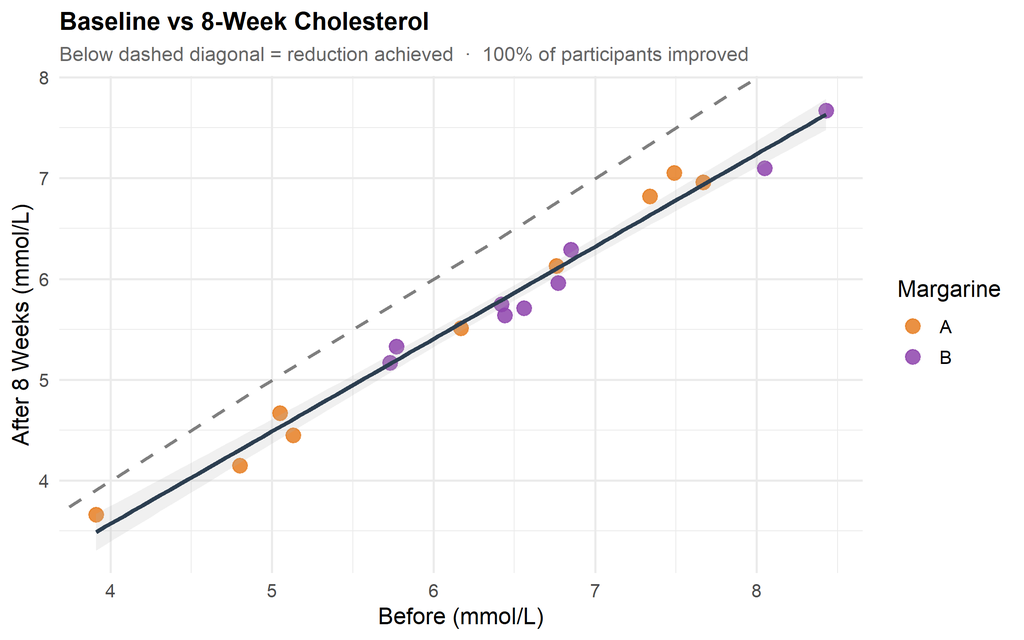

Figure 4: Every point sits below the diagonal, confirming universal reduction. Scatter around the regression line reflects variation in baseline, not direction of change.

```r
ggplot(chol, aes(Before, After8weeks, color=Margarine)) +
  geom_point(size=3.5, alpha=0.85) +
  geom_smooth(method="lm", se=TRUE, aes(group=1), color="#2c3e50", fill="grey70", alpha=0.2) +
  geom_abline(slope=1, intercept=0, linetype="dashed", color="grey50", linewidth=1) +
  scale_color_manual(values=c("A"="#e67e22","B"="#8e44ad")) +
  labs(title="Baseline vs 8-Week Cholesterol",
       subtitle="Below dashed diagonal = reduction achieved  ·  100% of participants improved",
       x="Before (mmol/L)", y="After 8 Weeks (mmol/L)", color="Margarine") + mytheme
```

## 4. Individual Variation

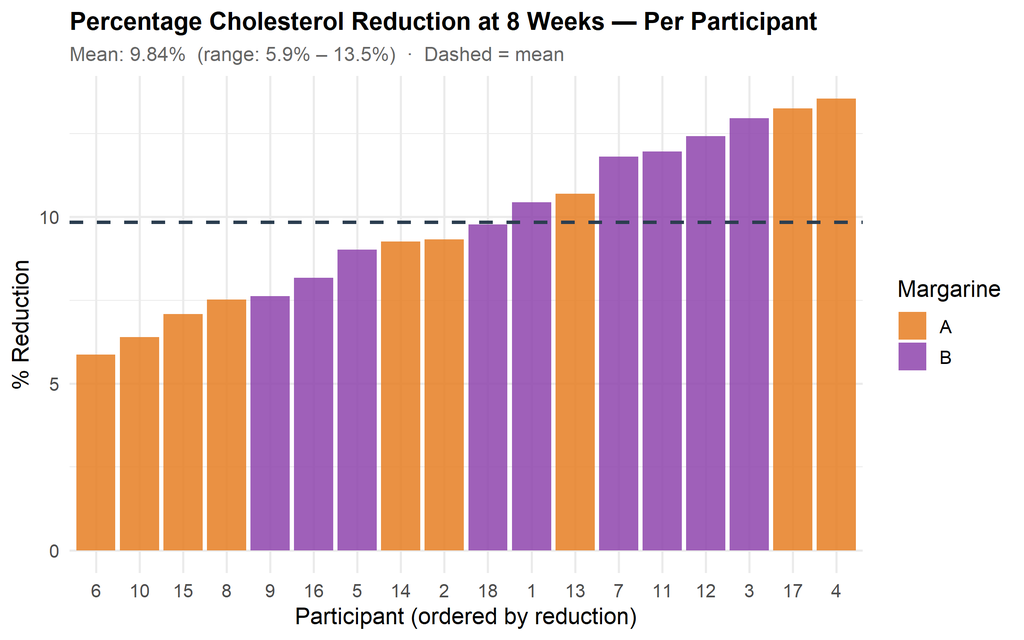

```r
ggplot(chol, aes(x=reorder(as.factor(ID), pct_reduction_8wk),
                 y=pct_reduction_8wk, fill=Margarine)) +
  geom_col(alpha=0.85) +
  geom_hline(yintercept=mean(chol$pct_reduction_8wk),
             linetype="dashed", color="#2c3e50", linewidth=1) +
  scale_fill_manual(values=c("A"="#e67e22","B"="#8e44ad")) +
  labs(title="Percentage Cholesterol Reduction at 8 Weeks — Per Participant",
       subtitle=paste0("Mean: ",round(mean(chol$pct_reduction_8wk),2),
                       "%  (range: ",round(min(chol$pct_reduction_8wk),1),
                       "% – ",round(max(chol$pct_reduction_8wk),1),
                       "%)  ·  Dashed = mean"),
       x="Participant (ordered by reduction)", y="% Reduction", fill="Margarine") + mytheme
```

## 5. Key Insight: Does Baseline Cholesterol Predict Reduction?

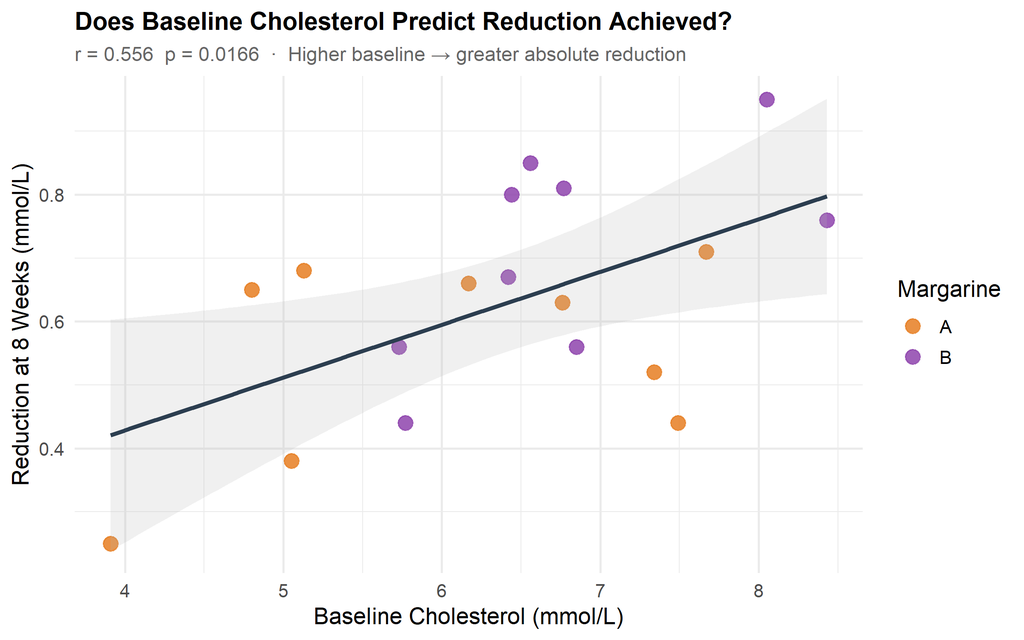

Figure 6: Significant positive correlation — those who needed it most benefited most.

```r
cor_res <- cor.test(chol$Before, chol$reduction_8wk)
lm_base <- lm(reduction_8wk ~ Before, data=chol)

ggplot(chol, aes(Before, reduction_8wk, color=Margarine)) +
  geom_point(size=3.5, alpha=0.85) +
  geom_smooth(method="lm", se=TRUE, aes(group=1), color="#2c3e50", fill="grey70", alpha=0.2) +
  scale_color_manual(values=c("A"="#e67e22","B"="#8e44ad")) +
  labs(title="Does Baseline Cholesterol Predict Reduction Achieved?",
       subtitle=paste0("r = ", round(cor_res$estimate,3),
                       "  p = ", round(cor_res$p.value,4),
                       "  ·  Higher baseline → greater absolute reduction"),
       x="Baseline Cholesterol (mmol/L)", y="Reduction at 8 Weeks (mmol/L)",
       color="Margarine") + mytheme
```

```r
summary(lm_base)
```

```
##
## Call:
## lm(formula = reduction_8wk ~ Before, data = chol)
##
## Residuals:
##      Min       1Q   Median       3Q      Max
## -0.27904 -0.12825 -0.01823  0.15401  0.20843
##
## Coefficients:
##             Estimate Std. Error t value Pr(>|t|)
## (Intercept)  0.09513    0.20283   0.469   0.6454
## Before       0.08330    0.03115   2.674   0.0166 *
## ---
## Signif. codes:  0 '***' 0.001 '**' 0.01 '*' 0.05 '.' 0.1 ' ' 1
##
## Residual standard error: 0.153 on 16 degrees of freedom
## Multiple R-squared:  0.3089, Adjusted R-squared:  0.2657
## F-statistic: 7.151 on 1 and 16 DF,  p-value: 0.01663
```

> **r = 0.556, p = 0.0166** — statistically significant. Participants entering the study with higher cholesterol achieved greater absolute reductions. This is clinically meaningful: the diet appears most impactful for those at higher cardiovascular risk.

## 6. Margarine Type: A vs B

### Are Both Types Individually Effective?

```r
within_results <- map_dfr(list(list(df=typeA, label="Margarine A"),
                               list(df=typeB, label="Margarine B")), function(m) {
  map_dfr(list(list(y=m$df$After4weeks, period="Before vs 4 Weeks"),
               list(y=m$df$After8weeks, period="Before vs 8 Weeks")), function(p) {
    tt <- t.test(m$df$Before, p$y, paired=TRUE)
    d  <- cohens_d_paired(m$df$Before, p$y)
    tibble(Type=m$label, Comparison=p$period,
           `Mean Diff`=round(mean(m$df$Before-p$y),4),
           `p-value`=round(tt$p.value,6),
           `Cohen's d`=round(d,4),
           Sig=ifelse(tt$p.value<0.05,"Yes **","No"))
  })
})
within_results
```

| Type | Comparison | Mean Diff | p-value | Cohen's d | Sig |
| --- | --- | --- | --- | --- | --- |
| Margarine A | Before vs 4 Weeks | 0.4856 | 4e-06 | 3.6993 | Yes ** |
| Margarine A | Before vs 8 Weeks | 0.5467 | 7e-06 | 3.4335 | Yes ** |
| Margarine B | Before vs 4 Weeks | 0.6467 | 1e-06 | 4.6190 | Yes ** |
| Margarine B | Before vs 8 Weeks | 0.7111 | 1e-06 | 4.3148 | Yes ** |

Both margarine types are individually effective — significant reductions at both timepoints, with large effect sizes.

### Is One Type Better Than the Other?

```r
map_dfr(list(
  list(a=typeA$Before,      b=typeB$Before,      tp="Before"),
  list(a=typeA$After4weeks, b=typeB$After4weeks, tp="After 4 Weeks"),
  list(a=typeA$After8weeks, b=typeB$After8weeks, tp="After 8 Weeks")
), function(p) {
  tt <- t.test(p$a, p$b, var.equal=FALSE)
  tibble(Timepoint=p$tp, `Mean A`=round(mean(p$a),3), `Mean B`=round(mean(p$b),3),
         `t-stat`=round(tt$statistic,4), `p-value`=round(tt$p.value,4),
         Conclusion=ifelse(tt$p.value<0.05,"Significant difference","No significant difference"))
})
```

| Timepoint | Mean A | Mean B | t-stat | p-value | Conclusion |
| --- | --- | --- | --- | --- | --- |
| Before | 6.036 | 6.780 | -1.3584 | 0.1958 | No significant difference |
| After 4 Weeks | 5.550 | 6.133 | -1.1090 | 0.2864 | No significant difference |
| After 8 Weeks | 5.489 | 6.069 | -1.1253 | 0.2801 | No significant difference |

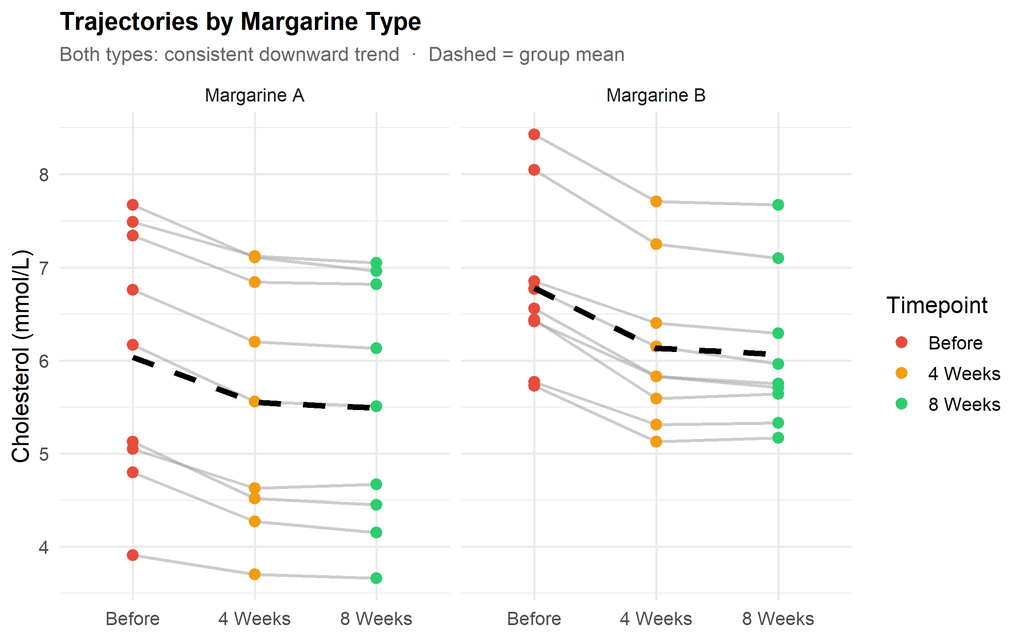

Figure 7: Both types follow the same downward trajectory — no evidence of a meaningful difference.

```r
ggplot(chol_long, aes(Timepoint, Cholesterol, group=ID)) +
  geom_line(alpha=0.5, color="grey60", linewidth=0.8) +
  geom_point(aes(color=Timepoint), size=2.5) +
  stat_summary(aes(group=1), fun=mean, geom="line",
               color="black", linewidth=1.5, linetype="dashed") +
  facet_wrap(~Margarine, labeller=labeller(Margarine=c("A"="Margarine A","B"="Margarine B"))) +
  scale_color_manual(values=c("Before"="#e74c3c","4 Weeks"="#f39c12","8 Weeks"="#2ecc71")) +
  labs(title="Trajectories by Margarine Type",
       subtitle="Both types: consistent downward trend  ·  Dashed = group mean",
       x=NULL, y="Cholesterol (mmol/L)", color="Timepoint") + mytheme
```

The groups were not significantly different at baseline, 4 weeks, or 8 weeks. Either margarine type can be recommended with equal confidence.

## 7. Summary

| Finding | Detail |
| --- | --- |
| **Significant reduction at 4 weeks** | −0.566 mmol/L, d = 3.64 (very large) |
| **Significant reduction at 8 weeks** | −0.629 mmol/L, d = 3.52 (very large) |
| **Continued improvement 4→8 weeks** | −0.063 mmol/L, p = 0.0015 |
| **Mean % reduction** | 9.84% (range: 5.9–13.5%) |
| **Rate** | 90% of reduction happens in first 4 weeks |
| **Baseline predicts benefit** | r = 0.556, p = 0.0166 — higher risk = more benefit |
| **Margarine type** | No significant difference — both equally effective |
| **Universal effect** | 100% of participants improved |

*Analysis in R — tidyverse, ggplot2, base stats. Mayerfeld Data Analytics Certificate — Week 2.*